# Assignment

Benedetto Lo Cicero

17/3/2020

# Executive Summary

Based we will try to train a predictive model on a dataset provide by HAR (http://groupware.les.inf.puc-rio.br/har) to try to predict the exercise that was performed. The dataset is composed of data collected by personal activity relatively trackers.

We’ll proceed as following:

- Preparation
- Process the data
- clean the data
- Explore the data
- Model different models
- Select the best model
- Predicting the classification of the model on the quiz set to answwr to the quiz questions

## Preparation

let’s start to load the packages that will be used; worth to be mentioned is the “dataPrepartion” that will easier the prepration

```r
library(tidyverse)
library(dplyr)
library(ggplot2)
library(lubridate)
library(caret)
library(dataPreparation)
library(ggcorrplot)
library(GGally)
library(readr)
library(janitor)
```

## Processing

we will start loading the training amd testing dataset, acknwldging that the testing set is the one used in the quiz, and NOT the one where to test my data

### load the data

to load the data we will use read_csv from the readr packages, becuase of the size of the dataset

the dataset is composed of `19622` rows and `159` columns let’s have a look at the structure of the dataset (only the first 15 features)

```r
df[,1:15] %>%  glimpse()
```

```
## Observations: 19,622
## Variables: 15
## $ user_name            <chr> "carlitos", "carlitos", "carlitos", "carlitos"...
## $ raw_timestamp_part_1 <dbl> 1323084231, 1323084231, 1323084231, 1323084232...
## $ raw_timestamp_part_2 <dbl> 788290, 808298, 820366, 120339, 196328, 304277...
## $ cvtd_timestamp       <chr> "05/12/2011 11:23", "05/12/2011 11:23", "05/12...
## $ new_window           <chr> "no", "no", "no", "no", "no", "no", "no", "no"...
## $ num_window           <dbl> 11, 11, 11, 12, 12, 12, 12, 12, 12, 12, 12, 12...
## $ roll_belt            <dbl> 1.41, 1.41, 1.42, 1.48, 1.48, 1.45, 1.42, 1.42...
## $ pitch_belt           <dbl> 8.07, 8.07, 8.07, 8.05, 8.07, 8.06, 8.09, 8.13...
## $ yaw_belt             <dbl> -94.4, -94.4, -94.4, -94.4, -94.4, -94.4, -94....
## $ total_accel_belt     <dbl> 3, 3, 3, 3, 3, 3, 3, 3, 3, 3, 3, 3, 3, 3, 3, 3...
## $ kurtosis_roll_belt   <chr> NA, NA, NA, NA, NA, NA, NA, NA, NA, NA, NA, NA...
## $ kurtosis_picth_belt  <chr> NA, NA, NA, NA, NA, NA, NA, NA, NA, NA, NA, NA...
## $ kurtosis_yaw_belt    <chr> NA, NA, NA, NA, NA, NA, NA, NA, NA, NA, NA, NA...
## $ skewness_roll_belt   <chr> NA, NA, NA, NA, NA, NA, NA, NA, NA, NA, NA, NA...
## $ skewness_roll_belt.1 <chr> NA, NA, NA, NA, NA, NA, NA, NA, NA, NA, NA, NA...
```

the first impression is that we might have columns totally filled with NA. Moreover this NA is coded as charachter and we have to enforce an R NA. The method I use is to convert them in number and the NA will be automatically set. This will be performed on all the columsn except the first 5 and the last one. In parallel we will convert the date into R type dates

We can now remove them column with all NA using the remove_empty function from janitor

```r
df_clean <- janitor::remove_empty(df_clean, which = c("cols"))
dim(df_clean)
```

```
## [1] 19622   153
```

the size didn’t shrink enough; we have to create a function removing all the columns with a percenteage of NA > a certain threshold.

we can then remove column containing >90 % NA; the dimensions of our dataset srhrink.

```r
df_filtered <- FilterTheData(df_clean,0.9)
dim(df_filtered)
```

```
## [1] 19622    59
```

as last action let’s remove all the columns linked to a timestamp and to a window , and not bringing additional information (excluding the class column our target variable):

we can now split the datset in training and test set.

```r
set.seed(17032020)

train_index <- createDataPartition(df_filtered$classe, p=0.6, list=FALSE)
train <- df_filtered[train_index,]
test <- df_filtered[-train_index,]
```

### Exploratory data analyses

we can run some exploratory analysis. We can check if there is any anormality in the data vs the user_name:

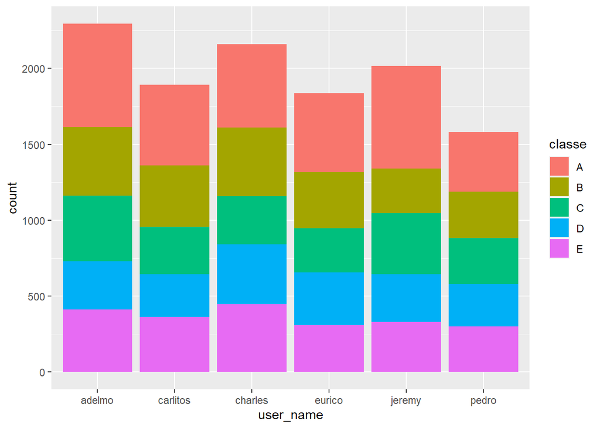

there is not an evident difference between the user and the activity class. we can have a look to the correlation between the numerical variables.

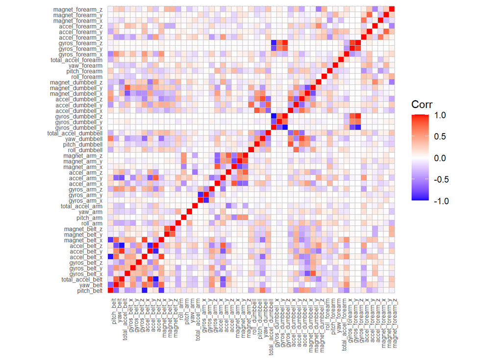

there are no indication of an evident correaltion between the variables, except for some subsets, where they looks highly correlated. it’s legitimate to think to apply a dimension reduction process such as PCA in order to remove all the features that might be highly correlated

## Machine learning models

for all the 3 models we will do the same: 1. fit the model 2. predict on the test set 3. build the classifcation matrix and store the figures to compare them

## Knn

```r
control <- trainControl(method="cv", number=5, allowParallel = TRUE)
grid <- expand.grid(k=6:10)
classifier <- train(classe ~ ., data=train_pca, method="knn",  tuneGrid=grid,trControl=control)
pred <- predict(classifier,test_pca)
CM <- confusionMatrix(pred,reference = test_pca$classe)
model_comparison <- merge(model_comparison,as.data.frame(CM$overall))
colnames(model_comparison)[ncol(model_comparison)] <- "KNn"
```

### eXtreme Gradient Boosting

```r
control <- trainControl(method="cv", number=5, allowParallel = TRUE)
grid <- expand.grid(nrounds=100,
                    lambda=0.5:0.9,
                    alpha=0.7,
                    eta=0.5:0.9)
classifier <- train(classe ~ ., data=train_pca, method="xgbLinear",  tuneGrid=grid,trControl=control)
```

```r
pred <- predict(classifier,test_pca)
CM <- confusionMatrix(pred,reference = test_pca$classe)
model_comparison <- merge(model_comparison,as.data.frame(CM$overall))
colnames(model_comparison)[ncol(model_comparison)] <- "eXGB"
```

## Model selection and application on the quiz dataset

the best model is eXGB tuned

```r
model_comparison %>% as_tibble()
```

```
## # A tibble: 343 x 3
##         NNt   KNn  eXGB
##       <dbl> <dbl> <dbl>
##  1 6.16e- 1 0.916 0.934
##  2 5.13e- 1 0.916 0.934
##  3 6.05e- 1 0.916 0.934
##  4 6.27e- 1 0.916 0.934
##  5 2.84e- 1 0.916 0.934
##  6 0.       0.916 0.934
##  7 9.45e-51 0.916 0.934
##  8 6.16e- 1 0.894 0.934
##  9 5.13e- 1 0.894 0.934
## 10 6.05e- 1 0.894 0.934
## # ... with 333 more rows
```

we have to preprocess the quiz data set using the previous created PCA components; we have to retain only the columns used when training the PCA and the last column (problem_id), that refers to the question number in the quiz:

```r
df_quiz_clean <- df_quiz
n_quiz <- df_quiz_clean$problem_id
df_quiz_clean$problem_id <- NULL
df_quiz_clean <- df_quiz_clean[,colnames(train_numeric)]
df_quiz_clean <- predict(pca_schema , df_quiz_clean)
```

with this model we have the following predictions:

```
## # A tibble: 20 x 2
##    n_quiz prediction
##    <fct>  <fct>
##  1 1      B
##  2 2      A
##  3 3      A
##  4 4      A
##  5 5      A
##  6 6      E
##  7 7      D
##  8 8      B
##  9 9      A
## 10 10     A
## 11 11     B
## 12 12     C
## 13 13     B
## 14 14     A
## 15 15     E
## 16 16     E
## 17 17     A
## 18 18     B
## 19 19     B
## 20 20     B
```